# The Dataset and Initial EDA

Author

Onesmus Kabui

## About the Dataset

This dataset contains data from individuals from Mexico, Peru and Columbia regarding their habits; eating habits and physical condition. By applying statistical and machine learning models, we can move beyond description and actually predict obesity levels. Each entry contains 17 variables and we have 2111 entries in total. 23% of the data was collected though a web platform directly from users and the rest was generated synthetically. From the feature variables estimates of the target variable are classified into different categories; Insufficient Weight, Normal Weight, Overweight Level I, Overweight Level II, Obesity Type I, Obesity Type II or Obesity Type III.

### Variables Overview

This dataset has 17 variables with one target variable. The variables can be described in terms of categories.

1. Demographic Information
- Gender
- Age – Age in years
- Height – Height in meters
- Weight – Weight in kilograms

  2. Eating Habits
- family_history_with_overweight – Whether close family members are overweight
- FAVC – Frequent consumption of high-calorie food (yes/no)
- FCVC – Frequency of vegetable consumption (scale)
- NCP – Number of main meals per day
- CAEC – Consumption of food between meals (snacking)
- SMOKE – Whether the individual smokes
- CH2O – Daily water intake (liters)
- SCC – Monitoring of daily calorie consumption (yes/no)
- CALC – Frequency of alcohol consumption

  3. Physical Condition & Lifestyle
- FAF – Physical activity frequency (hours per week)
- TUE – Time spent using technology devices (hours per day)
- MTRANS – Mode of transportation used (car, bike, public transport, walking, etc.)

  4. Target Variable
- NObeyesdad – Obesity Level (Insufficient Weight, Normal Weight, Overweight I, Overweight II, Obesity Type I, Obesity Type II, Obesity Type III)

### Initial EDA

```r
library(tidyverse)
library(ggplot2)
library(broom)
setwd("C:/Users/user/Desktop/datasets")
obesity_data<-read.csv("ObesityDataSet_raw.csv")
glimpse(obesity_data)
```

```
Rows: 2,111
Columns: 17
$ Gender                         <chr> "Female", "Female", "Male", "Male", "Ma…
$ Age                            <dbl> 21, 21, 23, 27, 22, 29, 23, 22, 24, 22,…
$ Height                         <dbl> 1.62, 1.52, 1.80, 1.80, 1.78, 1.62, 1.5…
$ Weight                         <dbl> 64.0, 56.0, 77.0, 87.0, 89.8, 53.0, 55.…
$ family_history_with_overweight <chr> "yes", "yes", "yes", "no", "no", "no", …
$ FAVC                           <chr> "no", "no", "no", "no", "no", "yes", "y…
$ FCVC                           <dbl> 2, 3, 2, 3, 2, 2, 3, 2, 3, 2, 3, 2, 3, …
$ NCP                            <dbl> 3, 3, 3, 3, 1, 3, 3, 3, 3, 3, 3, 3, 3, …
$ CAEC                           <chr> "Sometimes", "Sometimes", "Sometimes", …
$ SMOKE                          <chr> "no", "yes", "no", "no", "no", "no", "n…
$ CH2O                           <dbl> 2, 3, 2, 2, 2, 2, 2, 2, 2, 2, 3, 2, 3, …
$ SCC                            <chr> "no", "yes", "no", "no", "no", "no", "n…
$ FAF                            <dbl> 0, 3, 2, 2, 0, 0, 1, 3, 1, 1, 2, 2, 2, …
$ TUE                            <dbl> 1, 0, 1, 0, 0, 0, 0, 0, 1, 1, 2, 1, 0, …
$ CALC                           <chr> "no", "Sometimes", "Frequently", "Frequ…
$ MTRANS                         <chr> "Public_Transportation", "Public_Transp…
$ NObeyesdad                     <chr> "Normal_Weight", "Normal_Weight", "Norm…
```

```r
summary(obesity_data)
```

```
    Gender               Age            Height          Weight
 Length:2111        Min.   :14.00   Min.   :1.450   Min.   : 39.00
 Class :character   1st Qu.:19.95   1st Qu.:1.630   1st Qu.: 65.47
 Mode  :character   Median :22.78   Median :1.700   Median : 83.00
                    Mean   :24.31   Mean   :1.702   Mean   : 86.59
                    3rd Qu.:26.00   3rd Qu.:1.768   3rd Qu.:107.43
                    Max.   :61.00   Max.   :1.980   Max.   :173.00
 family_history_with_overweight     FAVC                FCVC
 Length:2111                    Length:2111        Min.   :1.000
 Class :character               Class :character   1st Qu.:2.000
 Mode  :character               Mode  :character   Median :2.386
                                                   Mean   :2.419
                                                   3rd Qu.:3.000
                                                   Max.   :3.000
      NCP            CAEC              SMOKE                CH2O
 Min.   :1.000   Length:2111        Length:2111        Min.   :1.000
 1st Qu.:2.659   Class :character   Class :character   1st Qu.:1.585
 Median :3.000   Mode  :character   Mode  :character   Median :2.000
 Mean   :2.686                                         Mean   :2.008
 3rd Qu.:3.000                                         3rd Qu.:2.477
 Max.   :4.000                                         Max.   :3.000
     SCC                 FAF              TUE             CALC
 Length:2111        Min.   :0.0000   Min.   :0.0000   Length:2111
 Class :character   1st Qu.:0.1245   1st Qu.:0.0000   Class :character
 Mode  :character   Median :1.0000   Median :0.6253   Mode  :character
                    Mean   :1.0103   Mean   :0.6579
                    3rd Qu.:1.6667   3rd Qu.:1.0000
                    Max.   :3.0000   Max.   :2.0000
    MTRANS           NObeyesdad
 Length:2111        Length:2111
 Class :character   Class :character
 Mode  :character   Mode  :character
```

```r
colSums(is.na(obesity_data))
```

```
                        Gender                            Age
                             0                              0
                        Height                         Weight
                             0                              0
family_history_with_overweight                           FAVC
                             0                              0
                          FCVC                            NCP
                             0                              0
                          CAEC                          SMOKE
                             0                              0
                          CH2O                            SCC
                             0                              0
                           FAF                            TUE
                             0                              0
                          CALC                         MTRANS
                             0                              0
                    NObeyesdad
                             0
```

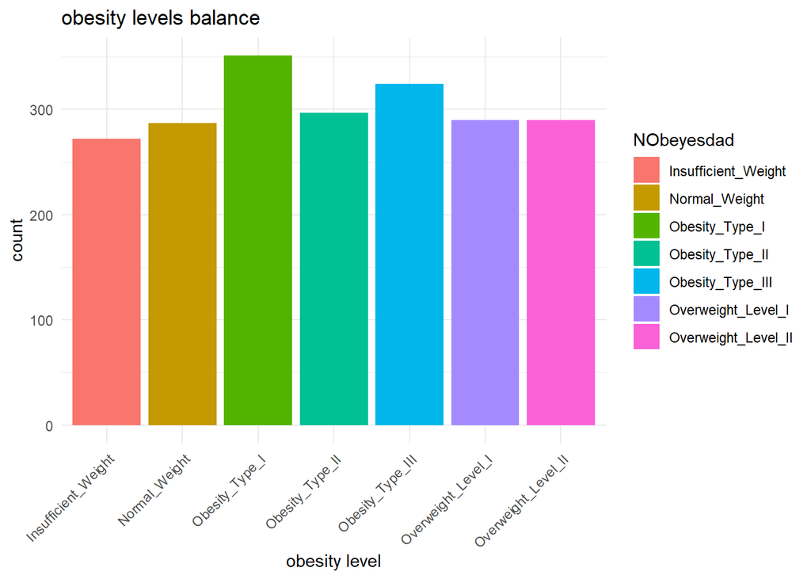

```r
#Understanding the target variable level balance
obesity_data %>%
  count(NObeyesdad) %>%
  ggplot(aes(x=NObeyesdad,y= n, fill=NObeyesdad))+
  geom_col()+
  labs(title = "obesity levels balance",x="obesity level",y="count")+
  theme_minimal()+
  theme(axis.text.x = element_text(angle = 45, hjust = 1)) #to stop overlapping for x axis labels
```

In the initial EDA we have made some key observations regarding our obesity data. Using glimpse we have discovered that the data type in the columns are double and in character form, some columns that contain character data type need to be converted to factor data type. We have also observed consistency in data for all numeric variables. This was also confirmed by the summary statistics with variable values falling within the reasonable range.

There are no missing values in this data for all variables. We also look at the target variable in depth and also plot to make sure the data is balanced and no classes dominate more. From the plot obesity_type_1 has the highest count while insufficient_weight has the lowest count. But on average the deviation between the variable counts is minimal we can conclude that the target variable is balanced.

## Data Cleaning and Preparation

#### Renaming Columns

```r
obesity_data<-obesity_data %>%
  rename(gender = Gender, age = Age, height = Height,weight = Weight,high_cal_food=FAVC,vegetable_consumption=FCVC,smoke=SMOKE, main_meals_number=NCP,snacking_between_meals=CAEC,water_intake=CH2O,calories_monitoring=SCC,alcohol_frequency=CALC,physical_activity=FAF,screen_time=TUE,transport_means=MTRANS,obesity_level=NObeyesdad)

glimpse(obesity_data,2)
```

```
Rows: 2,111
Columns: 17
$ gender                         <chr> …
$ age                            <dbl> …
$ height                         <dbl> …
$ weight                         <dbl> …
$ family_history_with_overweight <chr> …
$ high_cal_food                  <chr> …
$ vegetable_consumption          <dbl> …
$ main_meals_number              <dbl> …
$ snacking_between_meals         <chr> …
$ smoke                          <chr> …
$ water_intake                   <dbl> …
$ calories_monitoring            <chr> …
$ physical_activity              <dbl> …
$ screen_time                    <dbl> …
$ alcohol_frequency              <chr> …
$ transport_means                <chr> …
$ obesity_level                  <chr> …
```

We standardized variable names by removing abbreviations and capital letters to improve readability and consistency

### Checking data types

```r
str(obesity_data)
```

```
'data.frame':   2111 obs. of  17 variables:
 $ gender                        : chr  "Female" "Female" "Male" "Male" ...
 $ age                           : num  21 21 23 27 22 29 23 22 24 22 ...
 $ height                        : num  1.62 1.52 1.8 1.8 1.78 1.62 1.5 1.64 1.78 1.72 ...
 $ weight                        : num  64 56 77 87 89.8 53 55 53 64 68 ...
 $ family_history_with_overweight: chr  "yes" "yes" "yes" "no" ...
 $ high_cal_food                 : chr  "no" "no" "no" "no" ...
 $ vegetable_consumption         : num  2 3 2 3 2 2 3 2 3 2 ...
 $ main_meals_number             : num  3 3 3 3 1 3 3 3 3 3 ...
 $ snacking_between_meals        : chr  "Sometimes" "Sometimes" "Sometimes" "Sometimes" ...
 $ smoke                         : chr  "no" "yes" "no" "no" ...
 $ water_intake                  : num  2 3 2 2 2 2 2 2 2 2 ...
 $ calories_monitoring           : chr  "no" "yes" "no" "no" ...
 $ physical_activity             : num  0 3 2 2 0 0 1 3 1 1 ...
 $ screen_time                   : num  1 0 1 0 0 0 0 0 1 1 ...
 $ alcohol_frequency             : chr  "no" "Sometimes" "Frequently" "Frequently" ...
 $ transport_means               : chr  "Public_Transportation" "Public_Transportation" "Public_Transportation" "Walking" ...
 $ obesity_level                 : chr  "Normal_Weight" "Normal_Weight" "Normal_Weight" "Overweight_Level_I" ...
```

We notice that all variables represented as character data type are best represented as a categorical variables. So we can go ahead and transform all character variables to factor data types.

```r
obesity_data<-obesity_data %>%
  mutate(across(where(is.character),as.factor))
library(purrr)
obesity_data %>%
  select(where(is.factor)) %>%
  map(table)# see the different levels in the categoricall variables and their distribution.
```

```
$gender

Female   Male
  1043   1068

$family_history_with_overweight

  no  yes
 385 1726

$high_cal_food

  no  yes
 245 1866

$snacking_between_meals

    Always Frequently         no  Sometimes
        53        242         51       1765

$smoke

  no  yes
2067   44

$calories_monitoring

  no  yes
2015   96

$alcohol_frequency

    Always Frequently         no  Sometimes
         1         70        639       1401

$transport_means

           Automobile                  Bike             Motorbike
                  457                     7                    11
Public_Transportation               Walking
                 1580                    56

$obesity_level

Insufficient_Weight       Normal_Weight      Obesity_Type_I     Obesity_Type_II
                272                 287                 351                 297
   Obesity_Type_III  Overweight_Level_I Overweight_Level_II
                324                 290                 290
```

### Check for missing values

```r
colSums(is.na(obesity_data))
```

```
                        gender                            age
                             0                              0
                        height                         weight
                             0                              0
family_history_with_overweight                  high_cal_food
                             0                              0
         vegetable_consumption              main_meals_number
                             0                              0
        snacking_between_meals                          smoke
                             0                              0
                  water_intake            calories_monitoring
                             0                              0
             physical_activity                    screen_time
                             0                              0
             alcohol_frequency                transport_means
                             0                              0
                 obesity_level
                             0
```

There are no missing data.

## Exploratory Data Analysis

To capture the patterns and relationships in our data we carry out exploratory data analysis. To compare numeric variables with factor level target variable we use the ANOVA test and chi-square test to compare the relationship between categorical variables and target variables. After that we will see which features show which variables show strongest association with obesity level.

### Univariate analysis of Numeric Variables.

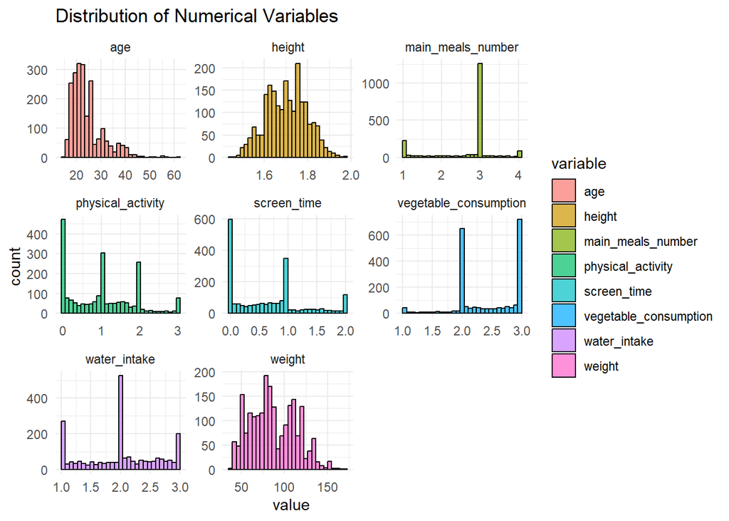

```r
obesity_num_vars<- c("age", "height", "weight", "vegetable_consumption",
              "main_meals_number", "water_intake",
              "physical_activity", "screen_time")
# Histograms to visualize distribution
obesity_data %>%
  select(all_of(obesity_num_vars)) %>%
  # pivot longer so ggplot2 can handle many variables in one plot
  pivot_longer(cols = everything(), names_to = "variable", values_to = "value") %>%
  ggplot(aes(x = value, fill = variable)) +
  geom_histogram(bins = 30, alpha = 0.7, color = "black") +
  # separate scale for each variable
  facet_wrap(~variable, scales = "free", ncol = 3) +
  theme_minimal() +
  labs(title = "Distribution of Numerical Variables")
```

From the univariate analysis of each numerical variable we can draw some conclusions about each variable.

Age~ from the histogram, we see that age has right skewness meaning that the participants in this data are relatively young.

height~the height variable has a normal distribution most participants having an average height

main meals number ~ variable shows an overwhelming number of people take 3 meals a day while others still take 1 and still 4 meals but very few.

physical activity~ most participants exercise 0-1 hour in a week with a small group doing 2-3 hours of exercise per week

screen time ~ most participants report less hours on the screens

vegetable consumption~ the histogram is left skewed meaning most participants report frequent vegetable consumption.

water intake~ participants water consumption is distributed across from 1 to 3 liters of water although many respondents report taking 2 liters of water.

### Univariate analysis of categorical variables

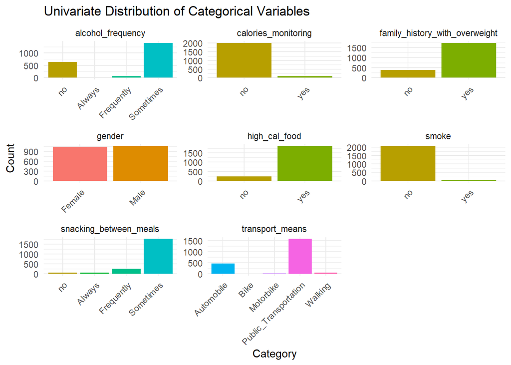

```r
obesity_factors <- obesity_data %>%
  select(where(is.factor)) %>%
  select(-obesity_level) %>%
  names()
obesity_data %>%
  pivot_longer(cols = all_of(obesity_factors),
               names_to = "variable",
               values_to = "value") %>%
  ggplot(aes(x = value, fill = value)) +
  geom_bar(show.legend = FALSE) +
  facet_wrap(~variable, scales = "free", ncol = 3) +
  theme_minimal() +
  theme(axis.text.x = element_text(angle = 45, hjust = 1)) +
  labs(title = "Univariate Distribution of Categorical Variables",
       x = "Category",
       y = "Count")
```

From the distribution of categorical variables;

Alcohol consumption falls into two groups of sometimes and no drinking indicating that most participants are light drinkers or non-drinkers..

Calories monitoring is heavily skewed towards no meaning almost all participants in the study do not monitor their calories intake which is expected, as few people typically monitor their calorie intake

family history with overweight also shows an overwhelming response of yes meaning many participants had at least one member who was overweight. This may introduce bias due to reliance on self-reported information

For gender which is actually very key we have a very fair representation of males and females.

high calories food many participants responded that they take high calorie food but we still had those who believed they consume low calorie food

obesity levels are very evenly distributed but type 1 obesity has the largest number of people classified in one group

For smoking most participants are non smokers so this may provide insights into how smoking relates to obesity levels.

snacking between meals as expected most people say they take snacks in between meals but to find out whether that has an effect in weight of a person we will see whether that can sufficiently predict someone obesity levels.

finally for categorical variables almost the whole population under study use either public transportation and automobiles which probably have the same level of physical movement but a small sample uses walking as their means of movement and that will be interesting to see how they predict obesity levels.

### Numeric variables vs Obesity level

```r
# ANOVA for each numeric predictor
num_results <- map_df(obesity_num_vars, function(var) {
  model <- aov(as.formula(paste(var, "~ obesity_level")), data=obesity_data)
  tidy <- broom::tidy(model)
  data.frame(
    Variable = var,
    p_value = tidy$p.value[1]
  )
})

num_results
```

```
               Variable       p_value
1                   age  3.592580e-88
2                height  1.685854e-44
3                weight  0.000000e+00
4 vegetable_consumption 3.732469e-123
5     main_meals_number  6.258632e-31
6          water_intake  2.837324e-18
7     physical_activity  7.653253e-20
8           screen_time  2.068782e-08
```

We applied ANOVA to test whether the mean values of numeric predictors differ across obesity categories. The null hypothesis stated that the means are equal across groups, while the alternative suggested at least one group differs. Results showed that all numeric variables (age, height, weight, vegetable consumption, main meals, water intake, physical activity, and screen time) had highly significant associations with obesity level (all p < 0.001). This indicates that differences in these behaviors and characteristics are strongly linked to variations in obesity status.

### Categorical vs target variables

```r
# Chi-square tests
cat_results <- map_df(obesity_factors, function(var) {
  tbl <- table(obesity_data[[var]], obesity_data$obesity_level)
  test <- chisq.test(tbl)
  data.frame(
    Variable = var,
    p_value = test$p.value
  )
})
cat_results
```

```
                        Variable       p_value
1                         gender 8.088897e-139
2 family_history_with_overweight 4.228017e-131
3                  high_cal_food  1.482236e-47
4         snacking_between_meals 7.383853e-159
5                          smoke  1.535424e-05
6            calories_monitoring  3.773176e-24
7              alcohol_frequency  5.287158e-61
8                transport_means  5.177915e-48
```

Chi-square tests show that all categorical variables are significantly associated with obesity level (all p < 0.05). This means factors like gender, family history, snacking, calorie monitoring, alcohol use, and transport choices are not independent of obesity outcomes, with family history and snacking showing especially strong links.This suggests that lifestyle and demographic features contain valuable predictive information, which justifies proceeding to supervised modelling

## Modelling

### Train test split

```r
library(caret)
obesity_index<-createDataPartition(obesity_data$obesity_level,p=0.8,list = FALSE)
obesity_train<-obesity_data[obesity_index,]
obesity_test<-obesity_data[-obesity_index,]
# Check class distribution in training and testing sets
prop.table(table(obesity_train$obesity_level))
```

```
Insufficient_Weight       Normal_Weight      Obesity_Type_I     Obesity_Type_II
          0.1289178           0.1360142           0.1661739           0.1407451
   Obesity_Type_III  Overweight_Level_I Overweight_Level_II
          0.1537552           0.1371969           0.1371969
```

```r
prop.table(table(obesity_test$obesity_level))
```

```
Insufficient_Weight       Normal_Weight      Obesity_Type_I     Obesity_Type_II
          0.1285714           0.1357143           0.1666667           0.1404762
   Obesity_Type_III  Overweight_Level_I Overweight_Level_II
          0.1523810           0.1380952           0.1380952
```

The split preserved class balance and in both sets all target levels are represented well.

### Logistic regression

Our baseline model will be multinomial logistic regression because our target is multiclass. From this model we can evaluate the linear relationship between the predictors and obesity levels.

```r
library(nnet)
obesity_multinom<- multinom(obesity_level~., data = obesity_train)
summary(obesity_multinom)
```

```
Call:
multinom(formula = obesity_level ~ ., data = obesity_train)

Coefficients:
                    (Intercept) genderMale       age    height    weight
Normal_Weight          104.1123  -4.278847 0.4991415 -129.3605  3.308731
Obesity_Type_I         210.5711 -30.709864 1.1381531 -673.2513 11.434381
Obesity_Type_II        102.0568  41.334800 4.3494712 -911.7491 16.032531
Obesity_Type_III      -123.4957 -94.993682 1.7990186 -636.5243 14.038797
Overweight_Level_I     111.7723 -11.222102 0.6333993 -309.6478  5.859537
Overweight_Level_II    145.4530 -10.312374 1.0157687 -452.7254  7.827319
                    family_history_with_overweightyes high_cal_foodyes
Normal_Weight                              -2.6047075       -1.8657986
Obesity_Type_I                             -3.1191102       -7.5481436
Obesity_Type_II                           -41.2518988      -28.0742199
Obesity_Type_III                          -54.1964366      -22.0588749
Overweight_Level_I                         -2.5655913        0.2336188
Overweight_Level_II                         0.9962695       -4.4791510
                    vegetable_consumption main_meals_number
Normal_Weight                   -3.127820        -1.4281905
Obesity_Type_I                  -5.271185        -0.1060674
Obesity_Type_II                -12.201466        11.6580018
Obesity_Type_III                45.691937        13.3084770
Overweight_Level_I              -4.486386        -1.1692326
Overweight_Level_II             -4.800903        -2.2046927
                    snacking_between_mealsFrequently snacking_between_mealsno
Normal_Weight                              -2.939054               6.00810121
Obesity_Type_I                             32.439242               0.06834716
Obesity_Type_II                          -131.556768              56.58320985
Obesity_Type_III                           96.722104              51.35349705
Overweight_Level_I                         -1.288679              13.48201232
Overweight_Level_II                         4.561869            -292.29707844
                    snacking_between_mealsSometimes smokeyes water_intake
Normal_Weight                              2.198705 75.39868    -4.439285
Obesity_Type_I                            51.736557 73.19997    -3.990869
Obesity_Type_II                           39.975907 74.29580   -22.784351
Obesity_Type_III                          60.234403 45.60579   -13.946177
Overweight_Level_I                         9.081797 70.88715    -4.917914
Overweight_Level_II                       17.412384 77.40542    -4.534858
                    calories_monitoringyes physical_activity screen_time
```

[output cut: 94 more lines]

```
Obesity_Type_I                  7.480840e-08
Obesity_Type_II                 1.793157e-14
Obesity_Type_III                         NaN
Overweight_Level_I             8.480217e-104
Overweight_Level_II             5.747207e-06
                    transport_meansPublic_Transportation transport_meansWalking
Normal_Weight                                   1.347745           2.2907137477
Obesity_Type_I                                  3.699480           2.9685964103
Obesity_Type_II                                 6.693485           0.0364574428
Obesity_Type_III                                4.336176           0.0001339752
Overweight_Level_I                              2.169722           1.6734734946
Overweight_Level_II                             2.710172           1.6497269184

Residual Deviance: 186.0339
AIC: 474.0339
```

```r
obesity_pred<- predict(obesity_multinom, newdata = obesity_test) #prediction
table(predicted= obesity_pred, actual=obesity_test$obesity_level)# confusion matrix
```

```
                     actual
predicted             Insufficient_Weight Normal_Weight Obesity_Type_I
  Insufficient_Weight                  51             6              0
  Normal_Weight                         3            51              0
  Obesity_Type_I                        0             0             66
  Obesity_Type_II                       0             0              1
  Obesity_Type_III                      0             0              0
  Overweight_Level_I                    0             0              0
  Overweight_Level_II                   0             0              3
                     actual
predicted             Obesity_Type_II Obesity_Type_III Overweight_Level_I
  Insufficient_Weight               0                0                  0
  Normal_Weight                     0                0                  1
  Obesity_Type_I                    3                0                  0
  Obesity_Type_II                  55                1                  0
  Obesity_Type_III                  1               63                  0
  Overweight_Level_I                0                0                 54
  Overweight_Level_II               0                0                  3
                     actual
predicted             Overweight_Level_II
  Insufficient_Weight                   0
  Normal_Weight                         0
  Obesity_Type_I                        1
  Obesity_Type_II                       1
  Obesity_Type_III                      1
  Overweight_Level_I                    6
  Overweight_Level_II                  49
```

```r
mean(obesity_pred==obesity_test$obesity_level)#classification accuracy
```

```
[1] 0.9261905
```

### Decision tree

From decision trees we will get more interpretability, capture non linear relationships as well as feature importance.

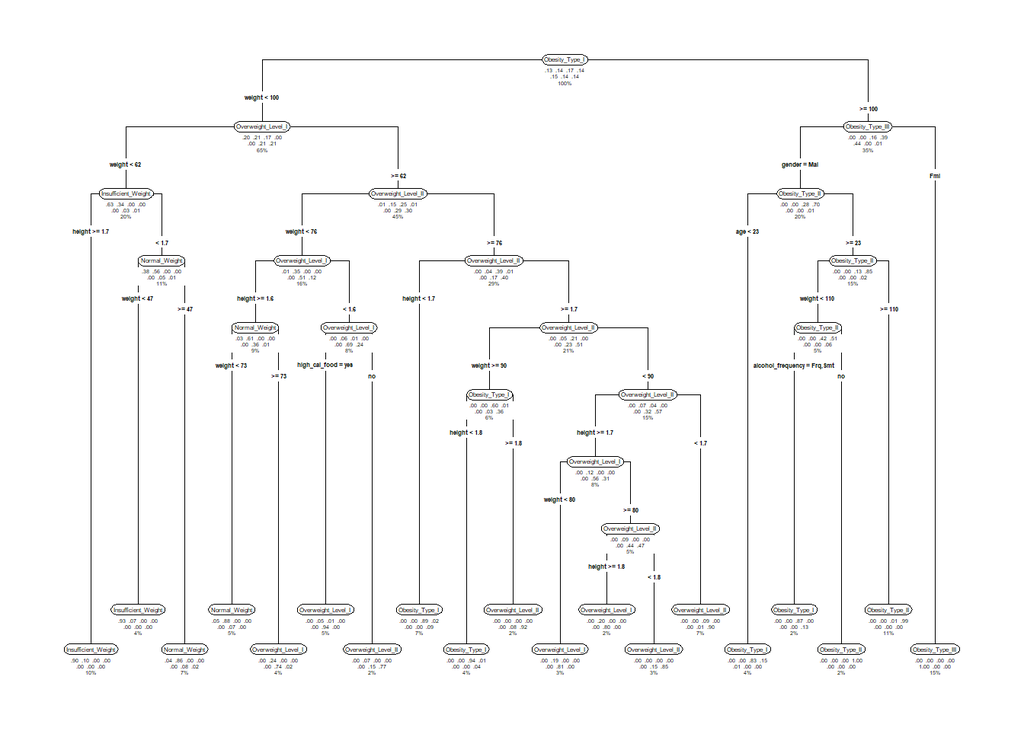

```r
library(rpart)
library(rpart.plot)
obesity_tree<-rpart(obesity_level~.,data = obesity_train,method = "class",)#fit decision tree model
rpart.plot(obesity_tree, type = 4, extra = 104, under = TRUE, faclen = 3)
```

```r
#prediction
obesity_pred2<-predict(obesity_tree, newdata = obesity_test,type = "class")
#confusion  matrix
table(predicted=obesity_pred2,actual=obesity_test$obesity_level)
```

```
                     actual
predicted             Insufficient_Weight Normal_Weight Obesity_Type_I
  Insufficient_Weight                  51             9              0
  Normal_Weight                         3            38              0
  Obesity_Type_I                        0             0             60
  Obesity_Type_II                       0             0              0
  Obesity_Type_III                      0             0              0
  Overweight_Level_I                    0             9              3
  Overweight_Level_II                   0             1              7
                     actual
predicted             Obesity_Type_II Obesity_Type_III Overweight_Level_I
  Insufficient_Weight               0                0                  0
  Normal_Weight                     0                0                  5
  Obesity_Type_I                    8                0                  0
  Obesity_Type_II                  50                0                  0
  Obesity_Type_III                  1               64                  0
  Overweight_Level_I                0                0                 49
  Overweight_Level_II               0                0                  4
                     actual
predicted             Overweight_Level_II
  Insufficient_Weight                   0
  Normal_Weight                         1
  Obesity_Type_I                        2
  Obesity_Type_II                       0
  Obesity_Type_III                      0
  Overweight_Level_I                    1
  Overweight_Level_II                  54
```

```r
#accuracy test
mean(obesity_pred2==obesity_test$obesity_level)
```

```
[1] 0.8714286
```

```r
#variable importance
obesity_tree$variable.importance
```

```
                        weight                         height
                   732.9146993                    506.4939233
                        gender          vegetable_consumption
                   289.5898971                    263.5182519
                           age              physical_activity
                   240.9849001                    122.5034810
             main_meals_number              alcohol_frequency
                   109.2679343                     72.8925605
        snacking_between_meals                   water_intake
                    64.0684837                     62.0866234
family_history_with_overweight                  high_cal_food
                    53.0837527                     41.8834074
                   screen_time                transport_means
                    32.8847711                      0.7713107
```

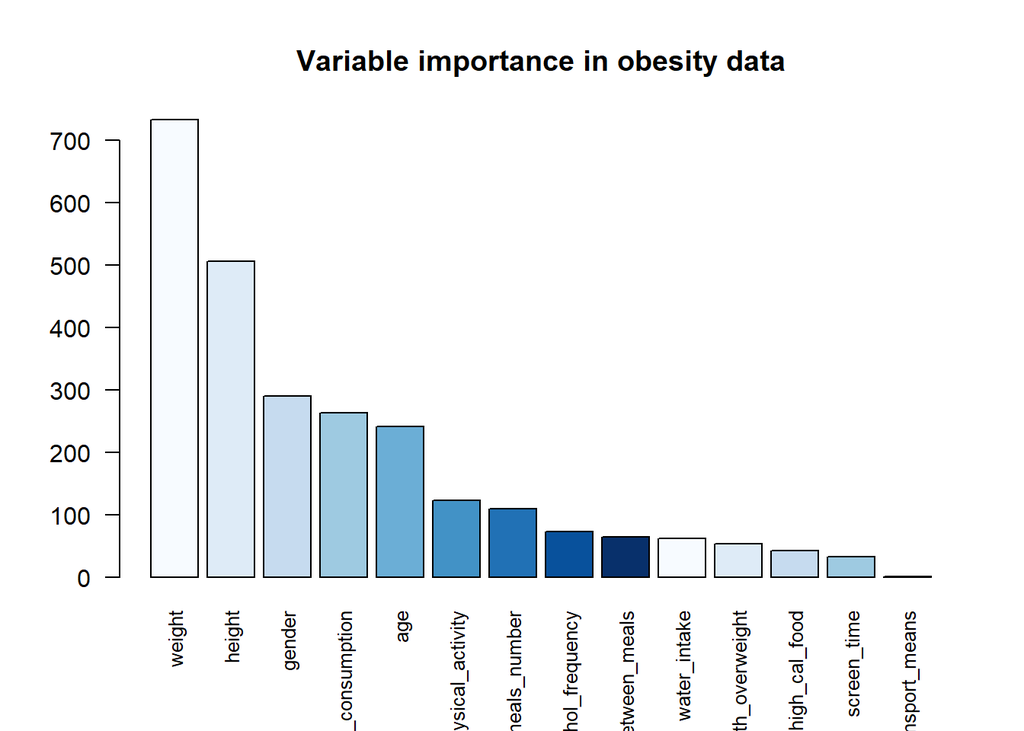

```r
#variable importance plot
variable_importance<-sort(obesity_tree$variable.importance,decreasing = TRUE)
barplot(variable_importance,main = "Variable importance in obesity data",las = 2, cex.names = 0.8,col = blues9)
```

This decision tree threw an over fitting warning but we initially proceeded to check how it performs. It had an accuracy score of 87%, lower than multi-nomial logistic regression from the more confusion in normal weight vs overweight1 and overweight2. From the variable importance, weight and height had the biggest influence in the splits of obesity level while screen time and means of transport has the least influence.

### Random Forests

Random forest is more versatile than single decision tree reducing the risk of overfitting and providing higher accuracy by combining many decision trees to reduce model variance.

```r
set.seed(66)
library(randomForest)
obesity_forest<-randomForest(obesity_level~.,obesity_train, ntree=500,mtry=3,importance=TRUE)#random forest with 500 trees
print(obesity_forest)
```

```
Call:
 randomForest(formula = obesity_level ~ ., data = obesity_train,      ntree = 500, mtry = 3, importance = TRUE)
               Type of random forest: classification
                     Number of trees: 500
No. of variables tried at each split: 3

        OOB estimate of  error rate: 4.49%
Confusion matrix:
                    Insufficient_Weight Normal_Weight Obesity_Type_I
Insufficient_Weight                 207            11              0
Normal_Weight                         2           221              0
Obesity_Type_I                        0             3            272
Obesity_Type_II                       0             1              1
Obesity_Type_III                      0             1              0
Overweight_Level_I                    0            24              1
Overweight_Level_II                   0             8              2
                    Obesity_Type_II Obesity_Type_III Overweight_Level_I
Insufficient_Weight               0                0                  0
Normal_Weight                     0                0                  3
Obesity_Type_I                    0                0                  1
Obesity_Type_II                 236                0                  0
Obesity_Type_III                  0              259                  0
Overweight_Level_I                0                0                201
Overweight_Level_II               0                0                  3
                    Overweight_Level_II class.error
Insufficient_Weight                   0 0.050458716
Normal_Weight                         4 0.039130435
Obesity_Type_I                        5 0.032028470
Obesity_Type_II                       0 0.008403361
Obesity_Type_III                      0 0.003846154
Overweight_Level_I                    6 0.133620690
Overweight_Level_II                 219 0.056034483
```

```r
#variable importance
importance(obesity_forest)
```

```
                               Insufficient_Weight Normal_Weight Obesity_Type_I
gender                                   18.584227    11.9499659      28.920042
age                                      37.940567     7.5368000      41.154752
height                                   30.187397    19.2803844      40.785216
weight                                   72.689662    56.9798854      71.757536
family_history_with_overweight           27.578458     4.4307175      26.339004
high_cal_food                            12.360389    -1.4777621      16.516865
vegetable_consumption                    22.999228    14.5804221      35.163607
main_meals_number                        26.185780     6.6540364      30.065424
snacking_between_meals                   28.927954    15.4657580      20.631067
smoke                                     4.813657    -0.7137195       1.520536
water_intake                             18.709977    18.0248212      27.228552
calories_monitoring                       4.726064    -2.4370918       7.347807
physical_activity                        21.042054    10.0616051      24.978822
screen_time                              25.250656    12.9705780      25.177594
alcohol_frequency                        21.625143    -1.6121426      27.081465
transport_means                          21.270918     1.2233693      18.523320
                               Obesity_Type_II Obesity_Type_III
gender                               26.556773        34.430020
age                                  36.156543        17.127462
height                               19.682894        14.554765
weight                               86.795677        57.744329
family_history_with_overweight       15.538555        15.845010
high_cal_food                         7.103130         8.143753
vegetable_consumption                26.584662        27.765556
main_meals_number                    24.024529        15.737880
snacking_between_meals               14.755363        14.517081
smoke                                 1.752913         2.586652
water_intake                         24.205783        10.054779
calories_monitoring                   4.127308         3.728301
physical_activity                    20.678003        12.101865
screen_time                          16.775447        15.585637
alcohol_frequency                    19.265735        15.097987
transport_means                      10.414462        12.282992
                               Overweight_Level_I Overweight_Level_II
gender                                  21.439257           25.170943
age                                     38.515125           43.209371
height                                  35.861622           41.831496
weight                                  58.625319           56.816324
family_history_with_overweight          21.416759           23.315480
```

[output cut: 13 more lines]

```
age                                       47.936099       143.277224
height                                    48.000157       132.811274
weight                                    95.271588       438.967826
family_history_with_overweight            30.140734        42.522979
high_cal_food                             25.854908        21.494648
vegetable_consumption                     36.714298       126.191113
main_meals_number                         35.798921        76.820863
snacking_between_meals                    30.348916        48.743945
smoke                                      4.827222         3.356557
water_intake                              41.039716        67.422554
calories_monitoring                       14.732862         8.486069
physical_activity                         34.889973        70.721554
screen_time                               30.720330        69.343741
alcohol_frequency                         31.601517        47.335936
transport_means                           26.519560        32.961566
```

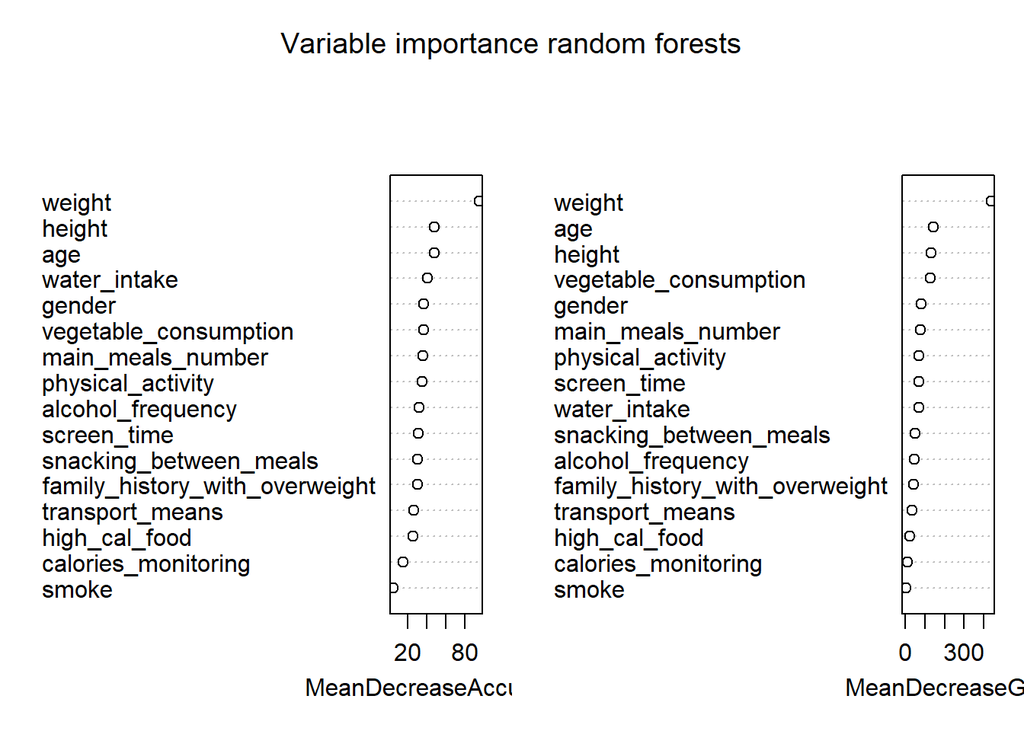

```r
varImpPlot(obesity_forest,main = "Variable importance random forests")
```

```r
#prediction
obesity_pred3<-predict(obesity_forest,newdata = obesity_test)
#confusion matrix
table(predicted=obesity_pred3,actual=obesity_test$obesity_level)
```

```
                     actual
predicted             Insufficient_Weight Normal_Weight Obesity_Type_I
  Insufficient_Weight                  48             0              0
  Normal_Weight                         6            56              0
  Obesity_Type_I                        0             0             64
  Obesity_Type_II                       0             0              0
  Obesity_Type_III                      0             0              0
  Overweight_Level_I                    0             1              2
  Overweight_Level_II                   0             0              4
                     actual
predicted             Obesity_Type_II Obesity_Type_III Overweight_Level_I
  Insufficient_Weight               0                0                  0
  Normal_Weight                     0                0                  4
  Obesity_Type_I                    1                0                  0
  Obesity_Type_II                  57                0                  0
  Obesity_Type_III                  1               64                  0
  Overweight_Level_I                0                0                 53
  Overweight_Level_II               0                0                  1
                     actual
predicted             Overweight_Level_II
  Insufficient_Weight                   0
  Normal_Weight                         5
  Obesity_Type_I                        0
  Obesity_Type_II                       0
  Obesity_Type_III                      0
  Overweight_Level_I                    4
  Overweight_Level_II                  49
```

```r
#accuracy test
mean(obesity_pred3==obesity_test$obesity_level)
```

```
[1] 0.9309524
```

### Feature scaling

I am going to encode categorical variables into numerical formats using dummy variables for categorical variables. With dummy numeric variables and scaled variables, and K-nearest neighbors uses distance metrics we can avoid disproportional influence in distance calculation.

```r
library(class)
library(caret)
# Identify predictors
predictors <- setdiff(names(obesity_train), "obesity_level")

# Create dummy variables for categorical predictors
dummies <- dummyVars(obesity_level ~ ., data= obesity_train)

train_transformed <- data.frame(predict(dummies, newdata = obesity_train))
train_transformed$obesity_level <- obesity_train$obesity_level

test_transformed <- data.frame(predict(dummies, newdata = obesity_test))
test_transformed$obesity_level <- obesity_test$obesity_level

str(train_transformed)
```

```
'data.frame':   1691 obs. of  32 variables:
 $ gender.Female                        : num  1 1 0 0 0 1 0 0 0 0 ...
 $ gender.Male                          : num  0 0 1 1 1 0 1 1 1 1 ...
 $ age                                  : num  21 21 23 27 22 23 22 24 22 26 ...
 $ height                               : num  1.62 1.52 1.8 1.8 1.78 1.5 1.64 1.78 1.72 1.85 ...
 $ weight                               : num  64 56 77 87 89.8 55 53 64 68 105 ...
 $ family_history_with_overweight.no    : num  0 0 0 1 1 0 1 0 0 0 ...
 $ family_history_with_overweight.yes   : num  1 1 1 0 0 1 0 1 1 1 ...
 $ high_cal_food.no                     : num  1 1 1 1 1 0 1 0 0 0 ...
 $ high_cal_food.yes                    : num  0 0 0 0 0 1 0 1 1 1 ...
 $ vegetable_consumption                : num  2 3 2 3 2 3 2 3 2 3 ...
 $ main_meals_number                    : num  3 3 3 3 1 3 3 3 3 3 ...
 $ snacking_between_meals.Always        : num  0 0 0 0 0 0 0 0 0 0 ...
 $ snacking_between_meals.Frequently    : num  0 0 0 0 0 0 0 0 0 1 ...
 $ snacking_between_meals.no            : num  0 0 0 0 0 0 0 0 0 0 ...
```

[output cut: 18 more lines]

```r
#Scaling numeric variables.
scaled<- preProcess(train_transformed, method = c("center", "scale"))

train_ready <- predict(scaled, train_transformed)
test_ready  <- predict(scaled, test_transformed)
str(train_ready)
```

```
'data.frame':   1691 obs. of  32 variables:
 $ gender.Female                        : num  1.015 1.015 -0.985 -0.985 -0.985 ...
 $ gender.Male                          : num  -1.015 -1.015 0.985 0.985 0.985 ...
 $ age                                  : num  -0.515 -0.515 -0.196 0.444 -0.355 ...
 $ height                               : num  -0.892 -1.96 1.029 1.029 0.815 ...
 $ weight                               : num  -0.87008 -1.17482 -0.37488 0.00604 0.1127 ...
 $ family_history_with_overweight.no    : num  -0.454 -0.454 -0.454 2.202 2.202 ...
 $ family_history_with_overweight.yes   : num  0.454 0.454 0.454 -2.202 -2.202 ...
 $ high_cal_food.no                     : num  2.83 2.83 2.83 2.83 2.83 ...
 $ high_cal_food.yes                    : num  -2.83 -2.83 -2.83 -2.83 -2.83 ...
 $ vegetable_consumption                : num  -0.787 1.093 -0.787 1.093 -0.787 ...
 $ main_meals_number                    : num  0.409 0.409 0.409 0.409 -2.156 ...
 $ snacking_between_meals.Always        : num  -0.154 -0.154 -0.154 -0.154 -0.154 ...
 $ snacking_between_meals.Frequently    : num  -0.356 -0.356 -0.356 -0.356 -0.356 ...
 $ snacking_between_meals.no            : num  -0.154 -0.154 -0.154 -0.154 -0.154 ...
```

[output cut: 18 more lines]

```r
# Separate predictors and labels
train_x <- subset(train_ready, select = -obesity_level)
train_y <- train_ready$obesity_level

test_x  <- subset(test_ready, select = -obesity_level)
test_y  <- test_ready$obesity_level
```

### K Nearest Neighbors

K nearest neighbors works by finding K most similar data points in a training set to a new unclassified point and in our case assigning it to the level with the majority of the K neighbors.

```r
set.seed(66)
obesity_pred4 <- knn(train = train_x,
                test  = test_x,
                cl    = train_y,
                k     = 3) # kNN with k =3

# Confusion matrix
table(predicted = obesity_pred4, actual = test_y)
```

```
                     actual
predicted             Insufficient_Weight Normal_Weight Obesity_Type_I
  Insufficient_Weight                  47            11              1
  Normal_Weight                         6            29              4
  Obesity_Type_I                        0             0             55
  Obesity_Type_II                       0             1              0
  Obesity_Type_III                      0             0              0
  Overweight_Level_I                    0             6              2
  Overweight_Level_II                   1            10              8
                     actual
predicted             Obesity_Type_II Obesity_Type_III Overweight_Level_I
  Insufficient_Weight               0                0                  5
  Normal_Weight                     1                0                  3
  Obesity_Type_I                    3                0                  3
  Obesity_Type_II                  54                0                  0
  Obesity_Type_III                  0               64                  0
  Overweight_Level_I                0                0                 46
  Overweight_Level_II               1                0                  1
                     actual
predicted             Overweight_Level_II
  Insufficient_Weight                   1
  Normal_Weight                         6
  Obesity_Type_I                        3
  Obesity_Type_II                       0
  Obesity_Type_III                      0
  Overweight_Level_I                    4
  Overweight_Level_II                  44
```

```r
# Accuracy
mean(obesity_pred4 == test_y)
```

```
[1] 0.8071429
```

### Conclusions and Recommendations

**Public Health Application**

The high accuracy of the Random Forest model suggests it could be implemented in clinical or public health screening tools to rapidly and reliably classify an individual’s obesity risk based on easily collected data. This early, accurate classification can facilitate timely, targeted health interventions.

**Limitations**

This study is limited by a single data set. This data should be validated by diverse data geographically, to confirm it’s robustness in predicting obesity level and feature importance for different populations.

**Future work**

- Further tuning of the random forest model
- Regression task: generating BMI feature and predicting it as the response instead of obesity level factor levels.